# Transitioning To R: Tutorial Notes (Plus R Viz)

Kiara

2025-04-21

**Sources**: [R Tutorial on W3Schools](https://w3schools.tech/tutorial/r/index) and [Google Data Analytics](https://www.coursera.org/professional-certificates/google-data-analytics) Course 7. I also added a few notes while taking JHU’s [Genomic Data Science Specialization](https://www.coursera.org/specializations/genomic-data-science).

## RStudio

‘Tools’ menu -> **‘Keyboard Shortcuts Help’ (Alt + Shift + K)**

- 4 panes, ‘View’ menu -> ‘Panes’ -> ‘Show All Panes’.
  - The ‘History’ pane on the right allows us to copy any executed line directly to the console by double-clicking it.
  - When we have questions about a function/package, type a question mark before it (eg. `?print`) to return a page in the ‘Help’ pane.

## R Basics

### Variables

- To assign values, the typical way is via `<-` rather than `=` (the latter passes arguments to functions, though it can also be used for assignment).
  - You can also assign multiple variables in one line: `x <- y <- z <- 10`
  - There’s even the ‘right assignment’: `20 -> y`.
- Add an L to explicitly assign an integer value. `my_integer <- 42L`; `my_number <- 42.5` (“numeric” types are floats that contain decimals).
- `rnorm(n)` returns n random numbers.
- To check what type of data a variable holds, use the `class()` function. Note that Boolean types are called “logical”.

```r
test <- TRUE
random = rnorm(3)
print(class(test))
```

```
## [1] "logical"
```

```r
print(random)
```

```
## [1] -0.3280322 -0.2307111  1.0885019
```

```r
print(class(random))
```

```
## [1] "numeric"
```

#### Finding variables

- The `ls()` function lists all variables in ur current environment.
- To check if a specific variable exists, use the `exists()` function.
- The `rm()` function removes variables.

```r
print(ls())
```

```
## [1] "random" "test"
```

```r
rm(list = ls()) # Remove all and start with a clean state. Caution!!!
print(ls())
```

```
## character(0)
```

### Data structure overview

- Vectors: `c(x, y, z, ...)`. Simplest and most fundamental data structures in R, each containing a single piece of data of the **same type**, use `[]` to access.

```r
x = c(1,3,5)
names(x) = letters[4:6] # We can name the elements of a vector object.
print(x)
```

```
## d e f
## 1 3 5
```

```r
print(x[c('d','f')])
```

```
## d f
## 1 5
```

- Lists can contain **different types of data**. The feeling is sort of like `dict` in Python as we get to name the elements (like having keys for values). We can also directly create a list without having the elements named: `my_first_list <- list("apple", 42, TRUE, c(1, 2, 3))`.

```r
my_list <- list(
  name = "Alice",
  age = 30,
  likes = c("pizza", "coding", "cats")
)

print(my_list[2]) # Returns a separated list
```

```
## $age
## [1] 30
```

```r
# VALUES of elements are accessed using [[]] or $.
print(my_list$name)
```

```
## [1] "Alice"
```

```r
print(paste(my_list[[2]],"since the index in R starts from 1!!!!! not 0!!!!"))
```

```
## [1] "30 since the index in R starts from 1!!!!! not 0!!!!"
```

```r
# paste() or paste0() are for concatenation of strings; note that the former inserts spaces between elements.
print(my_list[["likes"]][2])
```

```
## [1] "coding"
```

```r
print(paste("also", my_list[[3]][2]))
```

```
## [1] "also coding"
```

- Matrices: rows and columns **all filled with the same type of data**.

```r
my_matrix <- matrix(1:9, nrow = 3, ncol = 3)
print(my_matrix[2, 3])
```

```
## [1] 8
```

```r
# Set rownames
rownames(my_matrix) = letters[1:3]
print(my_matrix)
```

```
##   [,1] [,2] [,3]
## a    1    4    7
## b    2    5    8
## c    3    6    9
```

```r
print(my_matrix['a',]) # Returns a *vector*
```

```
## [1] 1 4 7
```

```r
print(my_matrix['a', , drop=FALSE]) # Returns a *matrix* with only one row.
```

```
##   [,1] [,2] [,3]
## a    1    4    7
```

- Arrays: stacked matrices. Note that the values from the specified sequence are arranged vertically down the column!! Or we can add argument `byrow = True`.

```r
my_array <- array(2:13, dim = c(2,3,2))
print(my_array)
```

```
## , , 1
##
##      [,1] [,2] [,3]
## [1,]    2    4    6
## [2,]    3    5    7
##
## , , 2
##
##      [,1] [,2] [,3]
## [1,]    8   10   12
## [2,]    9   11   13
```

```r
print(my_array[1,2,2])
```

```
## [1] 10
```

- Factors: a data structure that stores **categorical data** where the data values are limited and usually based on a finite group. Think of them as **labels**.

```r
sizes <- factor(c("small", "medium", "large", "medium", "small"))
print(sizes)
```

```
## [1] small  medium large  medium small
## Levels: large medium small
```

```r
print(levels(sizes))
```

```
## [1] "large"  "medium" "small"
```

- Data frames: unlike matrices (store the same type of data), they are capable of holding **different types of data in each column**. Rlly just a list where each element in the list is of the same length (an example that illustrates this can be seen in one code chunk below with `as.list(df)`)

```r
students <- data.frame(
  name = c("Alice", "Bob", "Charlie"),
  age = c(22, 25, 23),
  age2 = c(22, "25", 23),  # Testing whether the same column allows for different data types. Ooooh so it coerces to <chr> automatically.
  grade = c("A", "B", "A")
)

print(students)
```

```
##      name age age2 grade
## 1   Alice  22   22     A
## 2     Bob  25   25     B
## 3 Charlie  23   23     A
```

```r
print(students$age)
```

```
## [1] 22 25 23
```

```r
print(students$age2)
```

```
## [1] "22" "25" "23"
```

```r
print(students[['name']]) # Can also be accessed like this, same as lists. Column-oriented.
```

```
## [1] "Alice"   "Bob"     "Charlie"
```

```r
print(students[students$age >=23, ])
```

```
##      name age age2 grade
## 2     Bob  25   25     B
## 3 Charlie  23   23     A
```

```r
# If we omit comma here, R treats it as column subsetting, not row subsetting!!! (since we use [rows, columns] to access elements)
print(students[students$age >=23])
```

```
##   age age2
## 1  22   22
## 2  25   25
## 3  23   23
```

- Regarding the output of `print(students[students$age >=23])`: it is actually interpreted as `students[, c(FALSE, TRUE, TRUE)]` so instead of rows the columns with index 2 and 3 are selected OvO!
  - Recall that a column in a spreadsheet can be considered as a feature/attribute. So it’s pretty intuitive for this default indexing (by column -> by **header**!!).
- We can use the `as.something()` function to convert between data structures. Or use the more general `as(object, "data_structure)` function inside the `methods` package.

```r
print(as.matrix(students))
```

```
##      name      age  age2 grade
## [1,] "Alice"   "22" "22" "A"
## [2,] "Bob"     "25" "25" "B"
## [3,] "Charlie" "23" "23" "A"
```

```r
print(as.list(students))
```

```
## $name
## [1] "Alice"   "Bob"     "Charlie"
##
## $age
## [1] 22 25 23
##
## $age2
## [1] "22" "25" "23"
##
## $grade
## [1] "A" "B" "A"
```

```r
library(methods)
as(students, "matrix")
```

```
##      name      age  age2 grade
## [1,] "Alice"   "22" "22" "A"
## [2,] "Bob"     "25" "25" "B"
## [3,] "Charlie" "23" "23" "A"
```

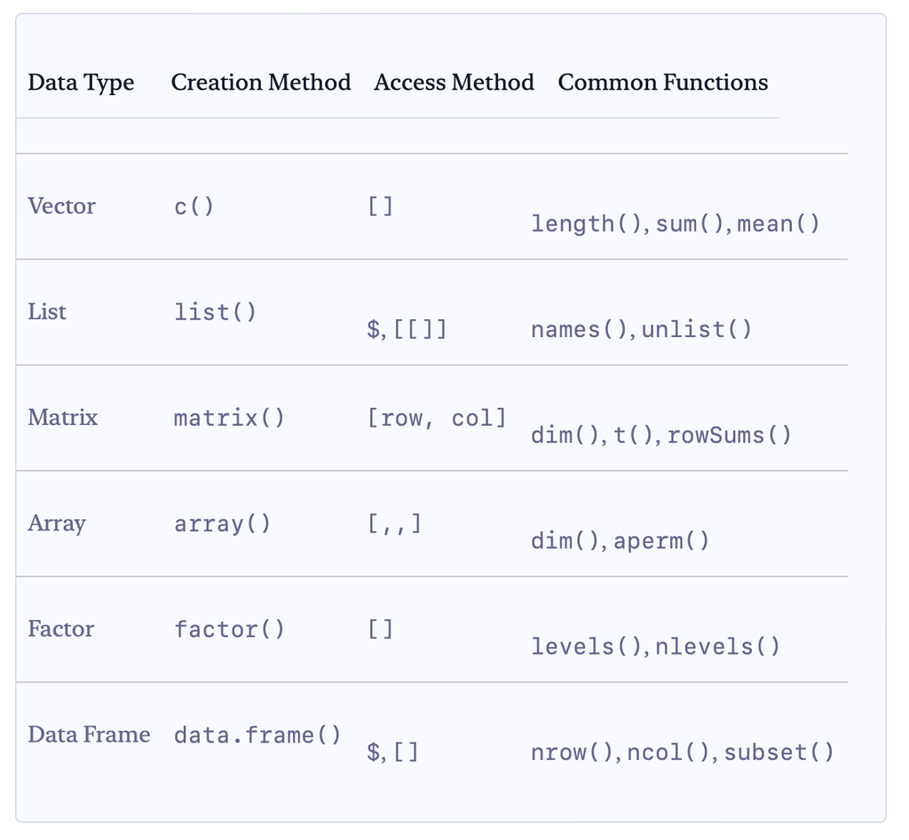

Screenshot from w3schools

### Operators

#### Arithmetic

- Modulus: `%%`
- Integer division: `%/%`
- Exponentiation: `^`

#### Relational

Same as Python.

#### Logical

- Element-wise AND:

```r
c(TRUE, FALSE, TRUE) & c(TRUE, TRUE, FALSE)
```

```
## [1]  TRUE FALSE FALSE
```

- Likewise, element-wise OR:

```r
c(TRUE, TRUE, FALSE) | c(FALSE, TRUE, FALSE)
```

```
## [1]  TRUE  TRUE FALSE
```

#### Miscellaneous

R also has some special operators that don’t fit neatly into the other categories.

```r
# Checks if an element is in a vector (similar to Python but with % around)
5 %in% c(1, 3, 5)
```

```
## [1] TRUE
```

```r
"cat" %in% c("goose", "duck")
```

```
## [1] FALSE
```

```r
# Creates a sequence. Unlike Python you can't specify the stride since it's either 1 (or -1 for descending sequences). (To explicitly customize the stride, use the function seq(from, to , by = stride) via the 'by' argument.)
1:5
```

```
## [1] 1 2 3 4 5
```

```r
class(1:5)
```

```
## [1] "integer"
```

```r
# Matrix multiplication
matrix(1:4, 2, 2) %*% matrix(5:8, 2, 2)
```

```
##      [,1] [,2]
## [1,]   23   31
## [2,]   34   46
```

```r
matrix(1:4, 2, 2)
```

```
##      [,1] [,2]
## [1,]    1    3
## [2,]    2    4
```

```r
# Again, note that when creating a matrix, the values are arranged vertically.
```

### Conditional and loop control statements

ok the way these are written is so extremely similar to Java (except no semicolons)

```r
a <- -2L
b <- FALSE
if (a >= 0 & b) {
  print("1")
} else if (!b) {
  print("2")
} else if (a < 0) {
  print("3")
} else {
  print("4")
}
```

```
## [1] "2"
```

- `switch` statement: a more readable alternative to a long `if-else if` chain. And it’s even more succinct in R with no `break`s!!!

```r
day <- '1'
switch(day,
  '1' = "Monday",
  '5' = "Friday",
)
```

```
## [1] "Monday"
```

- R has a nifty function `ifelse()` that combines an `if-else` statement into **a single line**:

```r
x <- 10
ifelse(x > 5, "Greater than 5", "Not greater than 5")
```

```
## [1] "Greater than 5"
```

- `next`: skips the rest of the current iteration and moves directly to the next iteration of the loop. **Equivalent of `continue`**.
- `repeat`: equivalent of `while True`. Accompanied by `break`.

```r
for (i in 1:10) {
  if (i %% 3 == 0) {
    next
  }
  print(i)
}
```

```
## [1] 1
## [1] 2
## [1] 4
## [1] 5
## [1] 7
## [1] 8
## [1] 10
```

```r
count <- 0
repeat {
  count <- count + 1
  if (count > 5) {
    break
  }
}
print(paste0("count = ",count))
```

```
## [1] "count = 6"
```

### Functions

#### Defining a function

```r
func_name <- function(argumen1, argumen2) {
  return_value1 <- c(argumen2, argumen1)
}

# calling it
test <- func_name(1,2)
test
```

```
## [1] 2 1
```

R only evaluates arguments when they’re actually used in the function (‘lazy evaluation’). Eg.

```r
lazy_function <- function(x, y) {
  print("I'm working!")
  return(x)
}
result <- lazy_function(5, stop("This won't run!"))
```

```
## [1] "I'm working!"
```

```r
# passing an error-causing stop() function as the second argument
print(result)
```

```
## [1] 5
```

```r
# our function runs without issues because it never uses the second argument
```

### Strings

- Concat by `paste()` and `paste0()`.
- String extraction is also done by `[start_index:end_index]`.
- Return the length: `nchar(string)`

```r
a <- "a b c"
print(nchar(a))
```

```
## [1] 5
```

```r
print(nchar("abc"))
```

```
## [1] 3
```

- Change the case: `toupper(string)` and `tolower(string)`
- Find and replace: `gsub(find_value, replacement, target_string)`

```r
gsub("cats", "dogs", "I like cats")
```

```
## [1] "I like dogs"
```

```r
gsub("cats", "dogs", "I like ") # whoa so no error message if value not found
```

```
## [1] "I like "
```

### Vectors

- The `:` operator returns a sequence of integers

```r
seq1 = 1:3
seq2 = c(1,2,3)
print(seq1)
```

```
## [1] 1 2 3
```

```r
print(class(seq1))
```

```
## [1] "integer"
```

```r
print(class(seq2))
```

```
## [1] "numeric"
```

- `seq(from, to, other keyword arguments...)`, like `arange()` and `linspace()`. Note again that keyword arguments are passed by `=`.
- `rep(value_to_be_repeated, other keyword arguments...)` for repeating values.

```r
seq3 <- seq(1, 5, by=2)
seq4 <- seq(1, 5, length.out=3)
seq3
```

```
## [1] 1 3 5
```

```r
seq4
```

```
## [1] 1 3 5
```

```r
# Repeating a single value
repeat_five <- rep(5, times = 3)
print(repeat_five)
```

```
## [1] 5 5 5
```

```r
# Repeating a vector
repeat_vector <- rep(c(1, 2), times = 3)
print(repeat_vector)
```

```
## [1] 1 2 1 2 1 2
```

```r
# Repeating each element
repeat_each <- rep(c(1, 2), each = 3)
print(repeat_each)
```

```
## [1] 1 1 1 2 2 2
```

- *Negative indexing* in R is used to *exclude elements* rather than accessing from the end.

```r
a <- c("a", "b", "c")
print(a[-2])
```

```
## [1] "a" "c"
```

- **You can also use logical vectors to access elements**, as shown in the data frame code chunk above.

```r
print(a[a != "b"]) # a[TRUE, FALSE, TRUE]
```

```
## [1] "a" "c"
```

- Vector arithmetic operations are done element-wise. If the lengths don’t match, R will **‘recycle’ the shorter vector by repeating it to match the length of the longer one**.
  - **This is not the same as broadcasting in numpy**, which allows the input arrays to have different numbers of *dimensions* but NOT different shapes (except when one of the input is 1) in the *same dimension* (compared right to left). So vector recycling is more flexible.
- `sort()` sorts the vector in ascending order; `rev()` reverses the order of elements.

### Lists

- Merging lists:

```r
list1 <- list(a = 1, b = 2)
# We can even throw functions into a list
list2 <- list(c = 3, d = 4, e = mean)
merged_list <- c(list1, list2)
print(merged_list)
```

```
## $a
## [1] 1
##
## $b
## [1] 2
##
## $c
## [1] 3
##
## $d
## [1] 4
##
## $e
## function (x, ...)
## UseMethod("mean")
## <bytecode: 0x142d28048>
## <environment: namespace:base>
```

- `unlist()`: converts/flattens the list into named vectors.

```r
print(list1)
```

```
## $a
## [1] 1
##
## $b
## [1] 2
```

```r
print(unlist(list1))
```

```
## a b
## 1 2
```

```r
# Reset the name for list1 to illustrate 'partial matching'
names(list1) = c('number','another_number')
print(list1$n) # Partial matching
```

```
## [1] 1
```

```r
# This can be so confusing (and dangerous when the names start in the same way)
names(list1) = c('number','number_another')
print(list1$n) # Outputs NULL.
```

[output not shown]

- `lapply(list, func_name)`: applies a function to all elements of a list (mapping). `sapply` simplifies the output. We can apply these functions for data frames as well since they are basically just lists whose elements are all of the same length.

```r
list3 = lapply(list(c(1,2),c(3,4),c(5,6,7,9)), max)
print(list3) # Still a list
```

```
## [[1]]
## [1] 2
##
## [[2]]
## [1] 4
##
## [[3]]
## [1] 9
```

```r
print(unlist(list3))
```

```
## [1] 2 4 9
```

```r
print(sapply(list3, max)) # Directly simplified as a vector
```

```
## [1] 2 4 9
```

### Matrices

- `t()` for transposing the matrix.

```r
# the second and third arguments are nrow and ncol; distinguish that from the argument when creating an array: it's a *single* argument that specifies the *dimension*.
a_matrix <- matrix(c(10, 20, 30, 40, 50, 60), 2, 3)
print(a_matrix)
```

```
##      [,1] [,2] [,3]
## [1,]   10   30   50
## [2,]   20   40   60
```

```r
# what happens if no comma when indexing
print(a_matrix[2]) # ok so the second element; this is different from data frame
```

```
## [1] 20
```

```r
print(a_matrix[2,])
```

```
## [1] 20 40 60
```

```r
print(a_matrix[,2])
```

```
## [1] 30 40
```

```r
print(t(a_matrix))
```

```
##      [,1] [,2]
## [1,]   10   20
## [2,]   30   40
## [3,]   50   60
```

### Arrays

*n*-dimensional (whereas data frames can only be *2D*); **all elements must be the same type** eg. all numeric or all character.

We can give names/labels to the indices of different dimensions. (note that these arguments passed to the function aren’t strictly keyword arguments; explicitly, they’re `dim()` (i.e., the shape) for the second argument and `dimnames()` for the third argument.)

```r
# Creating an array with named indices
student_scores <- array(
  c(85, 90, 78, 92, 88, 76, 95, 87, 82),
  c(3, 3),
  list(
    c("Alice", "Bob", "Charlie"),
    c("Math", "Science", "English")
  )
)
print(student_scores)
```

```
##         Math Science English
## Alice     85      92      95
## Bob       90      88      87
## Charlie   78      76      82
```

```r
# Updating a single score
student_scores["Charlie", "English"] <- 89
print(student_scores["Charlie", "English"])
```

```
## [1] 89
```

```r
# Updating an entire row
student_scores["Alice", ] <- c(91, 93, 97)
print(student_scores)
```

```
##         Math Science English
## Alice     91      93      97
## Bob       90      88      87
## Charlie   78      76      89
```

- Array functions/methods:
  - `dim()` and `dimnames()`: these two are not only keyword arguments when creating an array using `array()`, but also functions to get the corresponding parameters for a given array.
  - `length(array)`: returns the total number of elements
  - `apply(array, axis, func_name)`: applies a function (eg. those aggregate functions (is this a SQL term? nvm)) over **the specified axis** rather than element-wise. Regarding the second argument (axis), 1 for by row, etc.
  - `sweep(array, axis, aggregated_func(array))`: sweeps out array summaries/aggregations.
  - `aperm(array, permutation_vector, resize = TRUE)`: permutes the dimensions of an array. It rearranges the order of the dimensions of an array based on a specified permutation vector (`resize = TRUE` by default).

```r
arr <- array(1:24, dim = c(2, 3, 4))
# Permute dimensions (it's swapping the first and second dimensions rather than specifying the new shape!!)
result <- aperm(arr, perm = c(2, 1, 3))
dim(result)  # See? It's swapped.
```

```
## [1] 3 2 4
```

```r
arr
```

```
## , , 1
##
##      [,1] [,2] [,3]
## [1,]    1    3    5
## [2,]    2    4    6
##
## , , 2
##
##      [,1] [,2] [,3]
## [1,]    7    9   11
## [2,]    8   10   12
##
## , , 3
##
##      [,1] [,2] [,3]
## [1,]   13   15   17
## [2,]   14   16   18
##
## , , 4
##
##      [,1] [,2] [,3]
## [1,]   19   21   23
## [2,]   20   22   24
```

```r
result
```

```
## , , 1
##
##      [,1] [,2]
## [1,]    1    2
## [2,]    3    4
## [3,]    5    6
##
## , , 2
##
##      [,1] [,2]
## [1,]    7    8
## [2,]    9   10
## [3,]   11   12
##
## , , 3
##
##      [,1] [,2]
## [1,]   13   14
## [2,]   15   16
## [3,]   17   18
##
## , , 4
##
##      [,1] [,2]
## [1,]   19   20
## [2,]   21   22
## [3,]   23   24
```

### Factor

**A date type**. Representing **categories**.

```r
# Create a vector of collected pet preferences
pets <- c("Dog", "Cat", "Dog", "Fish", "Cat", "Dog", "Hamster")
# Convert the vector to a factor
pet_factor <- factor(pets)
# Factor is a data type
print(class(pets))
```

```
## [1] "character"
```

```r
print(class(pet_factor))
```

```
## [1] "factor"
```

```r
# Print the factor/categories
print(pet_factor)
```

```
## [1] Dog     Cat     Dog     Fish    Cat     Dog     Hamster
## Levels: Cat Dog Fish Hamster
```

```r
# Get a summary of the factor: returns the count of how many times each level appears in our factor.
summary(pet_factor)
```

```
##     Cat     Dog    Fish Hamster
##       2       3       1       1
```

**Levels** are the *unique categories* in the factor. Initially, R alphabetically orders the levels. We can reorder it by:

```r
print(levels(pet_factor))
```

```
## [1] "Cat"     "Dog"     "Fish"    "Hamster"
```

```r
pet_factor <- factor(pet_factor, levels = c("Dog", "Cat", "Fish", "Hamster"))
print(levels(pet_factor))
```

```
## [1] "Dog"     "Cat"     "Fish"    "Hamster"
```

Generating factor levels (**ordered** factors (`level1 < level2`) have data types as `<ord>`)

```r
# Generate a sequence of months (month.abb is a built-in R constant) to create a factor of month abbreviations
months <- factor(month.abb)
print(levels(months))
```

```
##  [1] "Apr" "Aug" "Dec" "Feb" "Jan" "Jul" "Jun" "Mar" "May" "Nov" "Oct" "Sep"
```

```r
# Create a factor with custom levels and specify the **order** we want the levels to be.
temperatures <- factor(c("Cold", "Hot", "Mild", "Hot", "Cold"),
                       levels = c("Cold", "Mild", "Hot"),
                       ordered = TRUE)
print(temperatures)
```

```
## [1] Cold Hot  Mild Hot  Cold
## Levels: Cold < Mild < Hot
```

```r
class(temperatures)
```

```
## [1] "ordered" "factor"
```

- Factor functions:
  - `nlevels()`: get the number of levels (i.e., unique categories in a factor).
  - `as.numeric()`: convert a factor to numeric (based on level order).
  - `as.character()`: convert a factor to character.
  - `table()`: create a frequency table of a factor.
  - `droplevels()`: remove *unused levels* from a factor.

### Packages

Besides Base R packages (“base” in column ‘Priority’ when running `installed.packages()`), other unloaded packages (shown as “recommended” in that column) require `library(package_name)` for a new session. After that, we can see the package in ‘System Library’ of the ‘Packages’ pane ticked. Click on the package name there to access the Help page.

- `available.packages()` shows packages available on CRAN (*the Comprehensive R Archive Network*, just the place where we downloaded R), which ensures that any R content not from Base R meets the required quality standards to be open to the public.
- Installing: use `install.packages("package_name")`. This command installs directly from CRAN. (When installing a package manually, first download it to the path and then `install.packages("path/to/package_file.tar.gz", repos = NULL, type = "source")`)
- Loading. Conflicts happen when packages have functions with the same names as other functions. The last package loaded is the one whose functions will be used over others.
- `old.packages()` checks for outdated packages
- `remove.packages("package_name")` uninstalls a package
- `packageVersion("package_name")` checks the version of a package
- `update.packages()` will update **all** ur packages (which will take a while), so use `install.packages("package_name")` **again** to update that one.

### Data frames

- Creating a df (*always have header rows (column names)!!!*)

```r
rm(list = ls())
students <- data.frame(
  name = c("Alice", "Bob", "Charlie"),
  age = c(22, 25, 23),
  grade = c("A", "B", "A-")
)
print(students)
```

```
##      name age grade
## 1   Alice  22     A
## 2     Bob  25     B
## 3 Charlie  23    A-
```

- Changing a column to factor-typed (also practicing to **access a column by its name/header and modify it**)

```r
students$grade <- factor(students$grade)
```

- Getting the **structure** and **summary** of our data frame:
  - **Here it calls rows ‘observations’ and columns ‘variables’.** Recall the records/fields notation.

```r
# Notice how 'grade' is now a factor with 3 levels.
str(students) # Stands for internal 'str'ucture not string
```

```
## 'data.frame':    3 obs. of  3 variables:
##  $ name : chr  "Alice" "Bob" "Charlie"
##  $ age  : num  22 25 23
##  $ grade: Factor w/ 3 levels "A","A-","B": 1 3 2
```

```r
summary(students) # Provides an overview of each column.
```

```
##      name                age        grade
##  Length:3           Min.   :22.00   A :1
##  Class :character   1st Qu.:22.50   A-:1
##  Mode  :character   Median :23.00   B :1
##                     Mean   :23.33
##                     3rd Qu.:24.00
##                     Max.   :25.00
```

```r
# summarize(students) this one (from dplyr rather than base R) is usually for grouped df after `group_by()` and allows for custom calculations!!! DISTINGUISH!!
```

- Extract and expand data

**Note that `cbind()` and `rbind()` are also used to add columns or rows (through a vector) to a matrix or an array, not just to a df (which requires binding of a df object).**

```r
# Get multiple columns
print(students[, c("name", "age")])
```

```
##      name age
## 1   Alice  22
## 2     Bob  25
## 3 Charlie  23
```

```r
# Add a new column
students$height <- c(165, 180, 175)

# Add a new row (similar to the rbind() function for rows, columns/new variables can also be added by cbind() in addition to $)
new_student <- data.frame(name = "David", age = 24, grade = "B+", height = 178)
students <- rbind(students, new_student)
print(students)
```

```
##      name age grade height
## 1   Alice  22     A    165
## 2     Bob  25     B    180
## 3 Charlie  23    A-    175
## 4   David  24    B+    178
```

```r
print(sapply(students,class))
```

```
##        name         age       grade      height
## "character"   "numeric"    "factor"   "numeric"
```

- **Merging** two data frames (equivalent to `INNER JOIN` but you don’t specify the overlapped column on which matching is based), ‘INNER’ since apparently ‘Kiara’ isn’t merged as the ‘name’ column isn’t matched between the two data frames)

```r
student_ids <- data.frame(
  name = c("Charlie", "Bob", "Alice", "David", "Kiara"),
  student_id = c("1a", "1b", "1c", "1d", "not_anyone_here")
)
students <- merge(students, student_ids)
print(students)
```

```
##      name age grade height student_id
## 1   Alice  22     A    165         1c
## 2     Bob  25     B    180         1b
## 3 Charlie  23    A-    175         1a
## 4   David  24    B+    178         1d
```

- **Melting** and **casting** data.

```r
#install.packages("reshape2")
library(reshape2)

melted_students <- melt(students, id.vars = 'name')
melted_students2 <- melt(students, id.vars = 'student_id')
print(melted_students)
```

```
##       name   variable value
## 1    Alice        age    22
## 2      Bob        age    25
## 3  Charlie        age    23
## 4    David        age    24
## 5    Alice      grade     A
## 6      Bob      grade     B
## 7  Charlie      grade    A-
## 8    David      grade    B+
## 9    Alice     height   165
## 10     Bob     height   180
## 11 Charlie     height   175
## 12   David     height   178
## 13   Alice student_id    1c
## 14     Bob student_id    1b
## 15 Charlie student_id    1a
## 16   David student_id    1d
```

```r
print(melted_students2)
```

```
##    student_id variable   value
## 1          1c     name   Alice
## 2          1b     name     Bob
## 3          1a     name Charlie
## 4          1d     name   David
## 5          1c      age      22
## 6          1b      age      25
## 7          1a      age      23
## 8          1d      age      24
## 9          1c    grade       A
## 10         1b    grade       B
## 11         1a    grade      A-
## 12         1d    grade      B+
## 13         1c   height     165
## 14         1b   height     180
## 15         1a   height     175
## 16         1d   height     178
```

```r
casted_students <- dcast(melted_students, variable ~ name)
print(casted_students)
```

```
##     variable Alice Bob Charlie David
## 1        age    22  25      23    24
## 2      grade     A   B      A-    B+
## 3     height   165 180     175   178
## 4 student_id    1c  1b      1a    1d
```

- Other data frame methods:
  - `head(df)` shows the first 6 rows of the data frame (so similar to pandas); `tail(df)` shows the last 6 rows of the data frame.
  - `nrow(df)` counts the number of rows; `ncol(df)` counts the number of columns.
  - `names(df)` gets the column names; `colnames(df)` is another way to get or set column names. `rownames(df)` gets or sets row names. (df rownames must be unique!!)
  - `dim(df)` returns the shape (rows and columns).
- With `df <- read.csv("file_name.csv")`, R can read a .csv file and store it in a data frame variable.
  - After installing and loading the *xlsx* package, we can also read an Excel file and store it as a data frame.
- Writing a data frame into a .csv: `write.csv(df_variable, "new_file_name.csv")`
  - `row.names = FALSE` excludes row names from the output; `quote = FALSE` prevents quoting of strings, `na = "NA"` specifies how to represent missing values.
  - `write.xlsx()` writes to an Excel file.